# Week 12 Summary

Exercises **What’s the difference between if and ifelse()? Carefully read the help and construct three examples that illustrate the key differences.**

Ifelse returns a value (often a string) with the yes or no depedning on what you set. if is boorlean. More accurately, if looks at one thing, while ifelse looks at each element.

**Write a greeting function that says “good morning”, “good afternoon”, or “good evening”, depending on the time of day. (Hint: use a time argument that defaults to lubridate::now(). That will make it easier to test your function.)**

```r
library(lubridate)
timeofday <-function(time = now()) {
  hr<-hour(time)
  if (hr < 12){
    print("Good Morning")
  } else if (hr < 17) {
    print("Good Afternoon")
  } else {
    print("Good Evening")
  }
}
timeofday()
```

```
[1] "Good Afternoon"
```

**Implement a fizzbuzz function. It takes a single number as input. If the number is divisible by three, it returns “fizz”. If it’s divisible by five it returns “buzz”. If it’s divisible by three and five, it returns “fizzbuzz”. Otherwise, it returns the number. Make sure you first write working code before you create the function.**

```r
fizzbuzz <- function(x) {
   stopifnot(length(x) == 1)
  stopifnot(is.numeric(x))
  if (!(x %% 3) && !(x %% 5)) {
    "fizzbuzz"
  } else if (!(x %% 3)) {
    "fizz"
  } else if (!(x %% 5)) {
    "buzz"
  } else {
    as.character(x)
  }
}
fizzbuzz(39)
```

```
[1] "fizz"
```

**How could you use cut() to simplify this set of nested if-else statements?

if (temp <= 0) { “freezing” } else if (temp <= 10) { “cold” } else if (temp <= 20) { “cool” } else if (temp <= 30) { “warm” } else { “hot” }**

```r
temp <- seq(-10, 50, by = 5)
cut(temp, c(-Inf, 0, 10, 20, 30, Inf),
  right = FALSE,
  labels = c("freezing", "cold", "cool", "warm", "hot")
)
```

```
 [1] freezing freezing cold     cold
 [5] cool     cool     warm     warm
 [9] hot      hot      hot      hot
[13] hot
Levels: freezing cold cool warm hot
```

**What happens if you use switch() with numeric values?**

It will return the argument that the numeric value references

**What does this switch() call do? What happens if x is “e”?

switch*(x, a = , b = “ab”, c = , d = “cd” ) Experiment, then carefully read the documentation.**

```r
x <-"e"
switch(x,
  a = ,
  b = "ab",
  c = ,
  d = "cd"
)

switchfxn <-function(x) {
 switch(x,
  a = ,
  b = "ab",
  c = ,
  d = "cd"
)
}

switchfxn("a")
switchfxn("b")
switchfxn("c")
switchfxn("d")
```

[output not shown]

Gives “ab” for a & b and gives “cd” for c & d, so will give the first non-missing argument value for the variable given and if none present will give the next one

**What does commas(letters, collapse = “-”) do? Why?**

```r
commas(letters, collapse = "-")
```

```
Error in commas(letters, collapse = "-") :
  could not find function "commas"
```

Seems to give an error. Due to not having the function commas present

**What does the trim argument to mean() do? When might you use it?**

It removes a fractions from 0 to 0.5. would use to measure central tendency.

**The default value for the method argument to cor() is c(“pearson”, “kendall”, “spearman”). What does that mean? What value is used by default?**

This means you can do one of the 3 main correlation methods. Pearson as it is first.

**Write for loops to:

Compute the mean of every column in mtcars.**

```r
library("tidyverse")
library("stringr")

output <- vector("double", ncol(mtcars))
names(output) <- names(mtcars)
for (i in names(mtcars)) {
  output[i] <- mean(mtcars[[i]])
}
output
```

```
       mpg        cyl       disp
 20.090625   6.187500 230.721875
        hp       drat         wt
146.687500   3.596563   3.217250
      qsec         vs         am
 17.848750   0.437500   0.406250
      gear       carb
  3.687500   2.812500
```

Determine the type of each column in nycflights13::flights.

```r
library(nycflights13)
output2 <- vector("list", ncol(flights))
names(output2) <- names(flights)
for (i in names(flights)) {
  output2[[i]] <-class(flights[[i]])
}
output2
```

[output not shown]

Compute the number of unique values in each column of iris.

```r
data("iris")
u_iris <-vector("double", ncol(iris))
names(u_iris) <-names(iris)
for (i in names(iris)) {
  u_iris[i] <-n_distinct(iris[i])
}
u_iris
```

```
Sepal.Length  Sepal.Width Petal.Length
          35           23           43
 Petal.Width      Species
          22            3
```

Combine your function writing and for loop skills:

Convert the song “99 bottles of beer on the wall” to a function. Generalise to any number of any vessel.

```r
bottles <- function(n) {
  if (n > 1) {
    str_c(n, " bottles")
  } else if (n == 1) {
    "1 bottle"
  } else {
    "no more bottles"
  }
}

beer_bottles <- function(total_bottles) {
  for (current_bottles in seq(total_bottles, 0)) {
cat(str_to_sentence(str_c(bottles(current_bottles), " of beer on the wall, ", bottles(current_bottles), " of beer.\n")))
    if (current_bottles > 0) {
      cat(str_c(
        "Take one down and pass it around, ", bottles(current_bottles - 1),
        " of beer on the wall.\n"
      ))
    } else {
      cat(str_c("Go to the store and buy some more, ", bottles(total_bottles), " of beer on the wall.\n"))                }
    cat("\n")
  }
}
beer_bottles(67)
```

[output not shown]

23.3.3 Exercises **Instead of using lm() to fit a straight line, you can use loess() to fit a smooth curve. Repeat the process of model fitting, grid generation, predictions, and visualisation on sim1 using loess() instead of lm(). How does the result compare to geom_smooth()?**

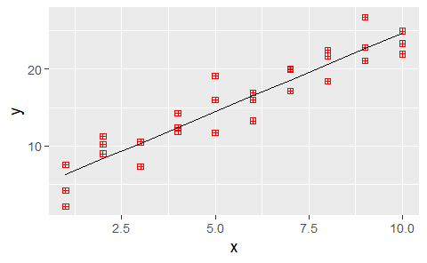

```r
sim1_loess <- loess(y ~ x, data = sim1)
sim1_lm <- lm(y ~ x, data = sim1)

grid_loess <- sim1 %>%
  add_predictions(sim1_loess)

sim1 <- sim1 %>%
  add_residuals(sim1_lm) %>%
  add_predictions(sim1_lm) %>%
  add_residuals(sim1_loess, var = "resid_loess") %>%
  add_predictions(sim1_loess, var = "pred_loess")
g1 <-ggplot(sim1, aes(x, y)) + geom_point(pch =12, color = "red") + geom_line(aes(x, y = pred))
g1
```

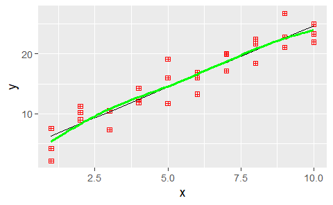

```r
g1 + geom_smooth(method = "loess", color = "green", se = FALSE, alpha = 1/5)
```

**add_predictions() is paired with gather_predictions() and spread_predictions(). How do these three functions differ?**

add_predictions() adds one model at a time unlike spread_predictions() and gather_predictions()

**What does geom_ref_line() do? What package does it come from? Why is displaying a reference line in plots showing residuals useful and important?**

geom_ref_line adds a reference line to a plot. It comes from the ggplot2 package. It helps you understand the spread of the data, and how the data fits a model.

**Why might you want to look at a frequency polygon of absolute residuals? What are the pros and cons compared to looking at the raw residuals?**

To understand your data, by knowing the extent of the spread of the residuals. However, you will only see absolute values so the information provided from negative residuals is lost.